# Analysis of gun sales in the USA, 1998 - 2018

- Introduction
- Data Wrangling
- Exploratory Data Analysis
- Conclusions
- List of References

## Introduction

This project explores the trends and tendencies of gun sales in the USA in the past 20 years. As a proxy for gun sales the FBI's National Criminal Background Checks System (NICS) information about background checks performed through the system is being used.

### Main dataset:

- **FBI NICS Firearm Background Check Data**

This dataset comes from the following [Github repository](https://github.com/BuzzFeedNews/nics-firearm-background-checks) and is based on the FBI's National Instant Criminal Background Check System. The NICS is used to determine whether a prospective buyer is eligible to buy firearms or explosives. Gun shops call into this system to ensure that each customer does not have a criminal record or isn’t otherwise ineligible to make a purchase.The FBI provides data on the number of firearm checks by month, state, and type, and currently covers the period of November 1998 – July 2018.

### Additional datasets:

- **State level data from census.gov**

This dataset includes census data for 2010 and 2016 per state with population related metrics, such as race, gender, education level, employment, etc.

- **USA 2016 Presidential Election by County**

This dataset contains the results of the 2016 US presidential elections as proportion of votes in favor of Republicans and Democrats per county. It comes from [OpenDataSoft](https://data.opendatasoft.com/explore/dataset/usa-2016-presidential-election-by-county%40public/table/).

### Important caveats of NICS dataset

The Github repository provides some important notes and caveats about the dataset:

> These statistics represent the number of firearm background checks initiated through the NICS. They do not represent the number of firearms sold. Based on varying state laws and purchase scenarios, a one-to-one correlation cannot be made between a firearm background check and a firearm sale.

A bit more background, from The Trace:

> The FBI’s background check numbers come with caveats: As seen in the late February-early March 2014 bubble, many checks are for concealed carry permits, not actual gun sales. Kentucky runs a new check on each concealed carry license holder each month. And of course, the FBI’s numbers don’t include private gun sales, many of which do not require a background check. A forthcoming study conducted by Harvard researchers found that roughly 40 percent of respondents had acquired their most recent firearm without going through a background check. Despite those vagaries, the FBI’s NICS numbers are widely accepted as the best proxy for total gun sales in a given time period.

Not all categories of background checks may be equally useful/pertinent to your research. When The New York Times analyzed NICS data in Dec. 2015, it included this methodological note:

> Note: Sales estimates are calculated from handgun, long gun and multiple-gun background checks. Permit checks and other categories of background checks are excluded. In California, multiple-gun checks were excluded because data was inconsistent. Because state laws differ, sales levels between states cannot be directly compared.

The authors of that NYT analysis describe how they used the NICS data to estimate gun sales:

> To convert background checks into estimated sales, we relied on a method suggested in the Small Arms Survey by Jurgen Brauer, a professor at Georgia Regents University. Each long gun and handgun check was counted as 1.1 sales. Each multiple-gun check was counted as two sales. Permit checks and other types of checks were omitted. The multiplier is an estimate based on Mr. Brauer's interviews with gun shop owners.

### Questions explored in the analysis

- What are the overall trends and tendencies of gun purchases?
- What is the split of sales by gun type?
- Which states have had the highest growth in gun registrations?
- What census data is most associated with high level of background checks per capita?

```python
import pandas as pd
import matplotlib.pyplot as plt
import seaborn as sns
from statsmodels.tsa.seasonal import seasonal_decompose
import datetime as dt
% matplotlib inline
```

## Data Wrangling

In this section we will focus on understadning and cleaning the data from the three datasets and finally creating a combined dataset that will help us explore the relationships between census and elections data per state and the gun sales data per state.

### NICS dataset

```python
# loading the gun dataset
df = pd.read_csv('gun_data.csv')

df.head()
```

|  | month | state | permit | permit_recheck | handgun | long_gun | other | multiple | admin | prepawn_handgun | ... | returned_other | rentals_handgun | rentals_long_gun | private_sale_handgun | private_sale_long_gun | private_sale_other | return_to_seller_handgun | return_to_seller_long_gun | return_to_seller_other | totals |
| --- | --- | --- | --- | --- | --- | --- | --- | --- | --- | --- | --- | --- | --- | --- | --- | --- | --- | --- | --- | --- | --- |
| 0 | 2018-08 | Alabama | 22465.0 | 0.0 | 5991.0 | 5741.0 | 218.0 | 274 | 0.0 | 12.0 | ... | 0.0 | 0.0 | 0.0 | 39.0 | 25.0 | 1.0 | 0.0 | 0.0 | 0.0 | 37227 |
| 1 | 2018-08 | Alaska | 218.0 | 0.0 | 2593.0 | 3057.0 | 220.0 | 181 | 0.0 | 5.0 | ... | 0.0 | 0.0 | 0.0 | 17.0 | 31.0 | 1.0 | 0.0 | 1.0 | 0.0 | 6818 |
| 2 | 2018-08 | Arizona | 12014.0 | 455.0 | 10833.0 | 6987.0 | 887.0 | 693 | 0.0 | 18.0 | ... | 1.0 | 0.0 | 0.0 | 30.0 | 17.0 | 4.0 | 1.0 | 1.0 | 0.0 | 34149 |
| 3 | 2018-08 | Arkansas | 5684.0 | 690.0 | 4809.0 | 5590.0 | 226.0 | 342 | 95.0 | 14.0 | ... | 0.0 | 0.0 | 0.0 | 20.0 | 13.0 | 6.0 | 0.0 | 0.0 | 0.0 | 20502 |
| 4 | 2018-08 | California | 38687.0 | 0.0 | 34617.0 | 25666.0 | 3117.0 | 0 | 0.0 | 0.0 | ... | 0.0 | 0.0 | 0.0 | 0.0 | 0.0 | 0.0 | 0.0 | 0.0 | 0.0 | 103019 |

5 rows × 27 columns

```python
df.shape
```

```
(13090, 27)
```

```python
df.info()
```

```
<class 'pandas.core.frame.DataFrame'>
RangeIndex: 13090 entries, 0 to 13089
Data columns (total 27 columns):
month                        13090 non-null object
state                        13090 non-null object
permit                       13066 non-null float64
permit_recheck               1705 non-null float64
handgun                      13070 non-null float64
long_gun                     13071 non-null float64
other                        6105 non-null float64
multiple                     13090 non-null int64
admin                        13067 non-null float64
prepawn_handgun              11147 non-null float64
prepawn_long_gun             11145 non-null float64
prepawn_other                5720 non-null float64
redemption_handgun           11150 non-null float64
redemption_long_gun          11149 non-null float64
redemption_other             5720 non-null float64
returned_handgun             2805 non-null float64
returned_long_gun            2750 non-null float64
returned_other               2420 non-null float64
rentals_handgun              1595 non-null float64
rentals_long_gun             1430 non-null float64
private_sale_handgun         3355 non-null float64
private_sale_long_gun        3355 non-null float64
private_sale_other           3355 non-null float64
return_to_seller_handgun     3080 non-null float64
return_to_seller_long_gun    3355 non-null float64
return_to_seller_other       2860 non-null float64
totals                       13090 non-null int64
dtypes: float64(23), int64(2), object(2)
memory usage: 2.7+ MB
```

Most of the datatypes seem correct, but in some columns there are significant amounts of null values.

First, let's convert the month column into datetime format and create a separate column with year

```python
# converting month from string to datetime and adding a separate column for year
df['month'] = df['month'].apply(lambda x: pd.to_datetime(x))
df['year'] = df['month'].apply(lambda x: str(x.year))
```

Second, let's see which metrics can be used as a proxy for gun sales

```python
# checking the top states based on mean monthly totals
df.groupby('state').totals.mean().astype(int).sort_values(ascending=False)
```

```
state
Kentucky                143903
Texas                    87985
California               85310
Illinois                 74265
Pennsylvania             59293
Florida                  54096
Ohio                     38456
Indiana                  36133
North Carolina           34839
Tennessee                33510
Georgia                  32509
Michigan                 32439
Alabama                  30047
Missouri                 29518
Washington               29177
Minnesota                28713
Colorado                 27592
Virginia                 26641
Wisconsin                23377
Louisiana                21000
New York                 20910
Oklahoma                 20563
Arizona                  20109
Utah                     19419
South Carolina           18051
Oregon                   17180
Arkansas                 16762
Mississippi              16018
West Virginia            14454
Connecticut              13994
Kansas                   11738
Massachusetts            11610
Iowa                     10391
New Mexico                9365
Maryland                  9172
Idaho                     9067
Montana                   8383
Nevada                    7789
New Hampshire             7136
Maine                     5650
South Dakota              5467
New Jersey                5200
Alaska                    5096
Nebraska                  5076
North Dakota              4225
Wyoming                   3989
Delaware                  2258
Vermont                   2197
Rhode Island              1313
Puerto Rico                922
Hawaii                     885
Guam                        69
Virgin Islands              68
District of Columbia        36
Mariana Islands              2
Name: totals, dtype: int32
```

Based on mean totals, Kentucky is the top state by far. However, this big difference compared to the second top state (Texas) seems too large. Let's look more in detail where this difference come from.

```python
df.query('state == "Kentucky"').head()
```

|  | month | state | permit | permit_recheck | handgun | long_gun | other | multiple | admin | prepawn_handgun | ... | rentals_handgun | rentals_long_gun | private_sale_handgun | private_sale_long_gun | private_sale_other | return_to_seller_handgun | return_to_seller_long_gun | return_to_seller_other | totals | year |
| --- | --- | --- | --- | --- | --- | --- | --- | --- | --- | --- | --- | --- | --- | --- | --- | --- | --- | --- | --- | --- | --- |
| 18 | 2018-08-01 | Kentucky | 393679.0 | 0.0 | 7250.0 | 6241.0 | 306.0 | 490 | 4.0 | 18.0 | ... | 0.0 | 0.0 | 30.0 | 45.0 | 1.0 | 0.0 | 1.0 | 0.0 | 411800 | 2018 |
| 73 | 2018-07-01 | Kentucky | 379409.0 | 0.0 | 6306.0 | 4537.0 | 295.0 | 341 | 2.0 | 17.0 | ... | 0.0 | 0.0 | 18.0 | 24.0 | 1.0 | 2.0 | 0.0 | 0.0 | 393583 | 2018 |
| 128 | 2018-06-01 | Kentucky | 395679.0 | 0.0 | 7130.0 | 4686.0 | 304.0 | 523 | 0.0 | 22.0 | ... | 0.0 | 0.0 | 26.0 | 25.0 | 2.0 | 1.0 | 0.0 | 0.0 | 411606 | 2018 |
| 183 | 2018-05-01 | Kentucky | 379571.0 | 0.0 | 7620.0 | 4696.0 | 344.0 | 434 | 3.0 | 10.0 | ... | 0.0 | 0.0 | 23.0 | 13.0 | 0.0 | 0.0 | 1.0 | 0.0 | 395487 | 2018 |
| 238 | 2018-04-01 | Kentucky | 390433.0 | 0.0 | 8893.0 | 6662.0 | 439.0 | 488 | 3.0 | 16.0 | ... | 0.0 | 0.0 | 9.0 | 23.0 | 2.0 | 0.0 | 0.0 | 1.0 | 409485 | 2018 |

5 rows × 28 columns

Looks like almost 400,000 permit checks were completed per month in Kentucky in the most recent months (around 10% of its whole population).

```python
# checking the proportion of permit checks in totals
state = df.groupby('state').mean()
state['permit_share'] = (100*(state['permit']) / state['totals']).round(2)

state[['permit_share', 'totals']].sort_values(by='permit_share',ascending=False)
```

| state | permit_share | totals |
| --- | --- | --- |
| Hawaii | 99.86 | 885.378151 |
| Kentucky | 85.15 | 143903.109244 |
| Virgin Islands | 79.59 | 68.689076 |
| Utah | 63.48 | 19419.752101 |
| Iowa | 63.44 | 10391.500000 |
| Illinois | 54.83 | 74265.810924 |
| Massachusetts | 52.96 | 11610.495798 |
| North Carolina | 50.26 | 34839.470588 |
| Connecticut | 50.03 | 13994.558824 |
| Nebraska | 49.96 | 5076.420168 |
| Michigan | 45.80 | 32439.260504 |
| Minnesota | 41.64 | 28713.735294 |
| Indiana | 39.91 | 36133.609244 |
| California | 34.69 | 85310.008403 |
| District of Columbia | 29.09 | 36.605042 |
| Washington | 26.37 | 29177.752101 |
| Georgia | 25.94 | 32509.865546 |
| New Hampshire | 25.35 | 7136.138655 |
| South Carolina | 23.25 | 18051.369748 |
| Idaho | 20.72 | 9067.037815 |
| Alabama | 18.10 | 30047.890756 |
| Maryland | 17.28 | 9172.310924 |
| New York | 16.79 | 20910.806723 |
| Tennessee | 16.60 | 33510.268908 |
| Arizona | 16.46 | 20109.420168 |
| Wisconsin | 16.26 | 23377.634454 |
| Texas | 15.47 | 87985.302521 |
| Arkansas | 14.08 | 16762.294118 |
| Nevada | 12.95 | 7789.319328 |
| Pennsylvania | 12.72 | 59293.365546 |
| North Dakota | 11.19 | 4225.903361 |
| Florida | 10.18 | 54096.134454 |
| Wyoming | 8.87 | 3989.894958 |
| Colorado | 8.13 | 27592.928571 |
| Montana | 7.97 | 8383.663866 |
| Missouri | 6.67 | 29518.983193 |
| Kansas | 6.26 | 11738.029412 |
| Ohio | 5.86 | 38456.521008 |
| Delaware | 5.17 | 2258.159664 |
| New Mexico | 4.71 | 9365.474790 |
| West Virginia | 4.37 | 14454.352941 |
| South Dakota | 3.61 | 5467.344538 |
| Mississippi | 3.30 | 16018.474790 |
| Oregon | 2.29 | 17180.000000 |
| Louisiana | 2.25 | 21000.092437 |
| Maine | 1.79 | 5650.184874 |
| Alaska | 1.33 | 5096.546218 |
| Virginia | 0.64 | 26641.697479 |
| Puerto Rico | 0.00 | 922.100840 |
| Rhode Island | 0.00 | 1313.361345 |
| Mariana Islands | 0.00 | 2.731092 |
| New Jersey | 0.00 | 5200.071429 |
| Vermont | 0.00 | 2197.235294 |
| Guam | 0.00 | 69.756303 |
| Oklahoma | 0.00 | 20563.453782 |

Out of average total monthly checks in Kentucky 85% correspond to permit checks. After doing some [research online](https://wfpl.org/kentucky-background-checks-stand-out/), turns out that

> Kentucky runs a new check on each concealed carry license holder each month.

This means that the number of permit checks does not actually reflect the background checks related to gun sales. The description of the dataset on [Github repository](https://github.com/BuzzFeedNews/nics-firearm-background-checks), also indicates that leaving out the permit checks might be a better approach.

> Not all categories of background checks may be equally useful/pertinent to your research. When The New York Times analyzed NICS data in Dec. 2015, it included this methodological note:

> > Note: Sales estimates are calculated from handgun, long gun and multiple-gun background checks. Permit checks and other categories of background checks are excluded.

We will leave out the permit checks and focus only on the checks related to specific type of gun sales

```python
# checking the missing data for the metrics that we are interested in
df[['handgun', 'long_gun', 'other', 'multiple', 'private_sale_handgun','private_sale_long_gun', 'private_sale_other']].info()
```

```
<class 'pandas.core.frame.DataFrame'>
RangeIndex: 13090 entries, 0 to 13089
Data columns (total 7 columns):
handgun                  13070 non-null float64
long_gun                 13071 non-null float64
other                    6105 non-null float64
multiple                 13090 non-null int64
private_sale_handgun     3355 non-null float64
private_sale_long_gun    3355 non-null float64
private_sale_other       3355 non-null float64
dtypes: float64(6), int64(1)
memory usage: 715.9 KB
```

Looks like most of the missing values appear in private sales data. Let's look more in detail at the private sales metric.

```python
# replacing null values with zeros
df = df.fillna(0)
```

```python
df['public_sales'] = df['handgun'] + df['long_gun'] + df['other'] + df['multiple']
df['private_sales'] = df['private_sale_handgun'] + df['private_sale_long_gun'] + df['private_sale_other']

df.groupby('state')[['private_sales', 'public_sales']].sum().sort_values(by='private_sales', ascending=False)
```

| state | private_sales | public_sales |
| --- | --- | --- |
| Washington | 48154.0 | 4609565.0 |
| New York | 29724.0 | 4058534.0 |
| Texas | 4426.0 | 15697518.0 |
| Missouri | 3970.0 | 6108450.0 |
| Massachusetts | 3488.0 | 1234958.0 |
| Delaware | 3102.0 | 503119.0 |
| Oklahoma | 2909.0 | 4243213.0 |
| Indiana | 2576.0 | 5052486.0 |
| Ohio | 2033.0 | 8218680.0 |
| Florida | 1840.0 | 11032570.0 |
| Georgia | 1259.0 | 4803369.0 |
| West Virginia | 1250.0 | 2747667.0 |
| Louisiana | 1239.0 | 4464978.0 |
| Kentucky | 1228.0 | 4336931.0 |
| North Carolina | 1199.0 | 3368121.0 |
| Michigan | 1175.0 | 4089319.0 |
| Maryland | 1139.0 | 1764983.0 |
| Arizona | 1070.0 | 3657073.0 |
| Alabama | 1051.0 | 5164105.0 |
| Minnesota | 1007.0 | 3856093.0 |
| Alaska | 984.0 | 1118811.0 |
| Arkansas | 879.0 | 2847858.0 |
| South Carolina | 770.0 | 2975020.0 |
| Kansas | 697.0 | 2441505.0 |
| Mississippi | 692.0 | 3158982.0 |
| Rhode Island | 661.0 | 310921.0 |
| Wisconsin | 654.0 | 4593392.0 |
| Idaho | 586.0 | 1498394.0 |
| North Dakota | 565.0 | 854306.0 |
| Montana | 484.0 | 1556788.0 |
| New Mexico | 430.0 | 1892500.0 |
| South Dakota | 426.0 | 1188298.0 |
| Maine | 421.0 | 1270544.0 |
| Wyoming | 369.0 | 788360.0 |
| New Hampshire | 301.0 | 1261084.0 |
| Iowa | 212.0 | 826986.0 |
| Nebraska | 163.0 | 581279.0 |
| Vermont | 124.0 | 522508.0 |
| Connecticut | 70.0 | 1629123.0 |
| Puerto Rico | 17.0 | 218723.0 |
| Virgin Islands | 4.0 | 4038.0 |
| Hawaii | 0.0 | 42.0 |
| Utah | 0.0 | 1626758.0 |
| Mariana Islands | 0.0 | 647.0 |
| California | 0.0 | 13164065.0 |
| Virginia | 0.0 | 6299070.0 |
| Illinois | 0.0 | 5218715.0 |
| Colorado | 0.0 | 6020316.0 |
| Tennessee | 0.0 | 6587230.0 |
| Guam | 0.0 | 16589.0 |
| Nevada | 0.0 | 1542958.0 |
| Pennsylvania | 0.0 | 12282407.0 |
| Oregon | 0.0 | 3991840.0 |
| New Jersey | 0.0 | 1237157.0 |
| District of Columbia | 0.0 | 6119.0 |

```python
df.groupby('year')['private_sales'].sum().sort_values(ascending=False)
```

```
year
2017    44762.0
2018    34462.0
2016    26641.0
2015    13457.0
2014     3164.0
2013      862.0
2005        0.0
1999        0.0
2000        0.0
2001        0.0
2002        0.0
2003        0.0
2004        0.0
2008        0.0
2006        0.0
2007        0.0
2009        0.0
2010        0.0
2011        0.0
2012        0.0
1998        0.0
Name: private_sales, dtype: float64
```

It seems that the data on private sales checks only appears from 2013 on and in some states there is no registers of private sales at all (even though there are background checks related to public sales in these states).

After checking the [federal regulations on background checks](https://lawcenter.giffords.org/gun-laws/policy-areas/background-checks/universal-background-checks/), it is clear that

> Although federal law requires licensed firearms dealers to perform background checks on prospective purchasers, it does not require unlicensed sellers to do so.

It is up to each state whether they will oblige private sales to go through the background check system.

Therefore for the purpose of this analysis we will focus only on checks related to public sales.

```python
# droping the columns that will not be used
df = df[['month', 'state', 'public_sales', 'handgun', 'long_gun', 'year']]

df.head()
```

|  | month | state | public_sales | handgun | long_gun | year |
| --- | --- | --- | --- | --- | --- | --- |
| 0 | 2018-08-01 | Alabama | 12224.0 | 5991.0 | 5741.0 | 2018 |
| 1 | 2018-08-01 | Alaska | 6051.0 | 2593.0 | 3057.0 | 2018 |
| 2 | 2018-08-01 | Arizona | 19400.0 | 10833.0 | 6987.0 | 2018 |
| 3 | 2018-08-01 | Arkansas | 10967.0 | 4809.0 | 5590.0 | 2018 |
| 4 | 2018-08-01 | California | 63400.0 | 34617.0 | 25666.0 | 2018 |

### Census dataset

```python
cens = pd.read_csv('U.S. Census Data.csv')
cens.drop(['Fact Note'], axis=1, inplace=True)

cens
```

|  | Fact | Alabama | Alaska | Arizona | Arkansas | California | Colorado | Connecticut | Delaware | Florida | ... | South Dakota | Tennessee | Texas | Utah | Vermont | Virginia | Washington | West Virginia | Wisconsin | Wyoming |
| --- | --- | --- | --- | --- | --- | --- | --- | --- | --- | --- | --- | --- | --- | --- | --- | --- | --- | --- | --- | --- | --- |
| 0 | Population estimates, July 1, 2016, (V2016) | 4,863,300 | 741,894 | 6,931,071 | 2,988,248 | 39,250,017 | 5,540,545 | 3,576,452 | 952,065 | 20,612,439 | ... | 865454 | 6651194 | 27,862,596 | 3,051,217 | 624,594 | 8,411,808 | 7,288,000 | 1,831,102 | 5,778,708 | 585,501 |
| 1 | Population estimates base, April 1, 2010, (V2... | 4,780,131 | 710,249 | 6,392,301 | 2,916,025 | 37,254,522 | 5,029,324 | 3,574,114 | 897,936 | 18,804,592 | ... | 814195 | 6346298 | 25,146,100 | 2,763,888 | 625,741 | 8,001,041 | 6,724,545 | 1,853,011 | 5,687,289 | 563,767 |
| 2 | Population, percent change - April 1, 2010 (es... | 1.70% | 4.50% | 8.40% | 2.50% | 5.40% | 10.20% | 0.10% | 6.00% | 9.60% | ... | 0.063 | 0.048 | 10.80% | 10.40% | -0.20% | 5.10% | 8.40% | -1.20% | 1.60% | 3.90% |
| 3 | Population, Census, April 1, 2010 | 4,779,736 | 710,231 | 6,392,017 | 2,915,918 | 37,253,956 | 5,029,196 | 3,574,097 | 897,934 | 18,801,310 | ... | 814180 | 6346105 | 25,145,561 | 2,763,885 | 625,741 | 8,001,024 | 6,724,540 | 1,852,994 | 5,686,986 | 563,626 |
| 4 | Persons under 5 years, percent, July 1, 2016, ... | 6.00% | 7.30% | 6.30% | 6.40% | 6.30% | 6.10% | 5.20% | 5.80% | 5.50% | ... | 0.071 | 0.061 | 7.20% | 8.30% | 4.90% | 6.10% | 6.20% | 5.50% | 5.80% | 6.50% |
| 5 | Persons under 5 years, percent, April 1, 2010 | 6.40% | 7.60% | 7.10% | 6.80% | 6.80% | 6.80% | 5.70% | 6.20% | 5.70% | ... | 0.073 | 0.064 | 7.70% | 9.50% | 5.10% | 6.40% | 6.50% | 5.60% | 6.30% | 7.10% |
| 6 | Persons under 18 years, percent, July 1, 2016,... | 22.60% | 25.20% | 23.50% | 23.60% | 23.20% | 22.80% | 21.10% | 21.50% | 20.10% | ... | 0.246 | 0.226 | 26.20% | 30.20% | 19.00% | 22.20% | 22.40% | 20.50% | 22.30% | 23.70% |
| 7 | Persons under 18 years, percent, April 1, 2010 | 23.70% | 26.40% | 25.50% | 24.40% | 25.00% | 24.40% | 22.90% | 22.90% | 21.30% | ... | 0.249 | 0.236 | 27.30% | 31.50% | 20.70% | 23.20% | 23.50% | 20.90% | 23.60% | 24.00% |
| 8 | Persons 65 years and over, percent, July 1, 2... | 16.10% | 10.40% | 16.90% | 16.30% | 13.60% | 13.40% | 16.10% | 17.50% | 19.90% | ... | 0.16 | 0.157 | 12.00% | 10.50% | 18.10% | 14.60% | 14.80% | 18.80% | 16.10% | 15.00% |
| 9 | Persons 65 years and over, percent, April 1, 2010 | 13.80% | 7.70% | 13.80% | 14.40% | 11.40% | 10.90% | 14.20% | 14.40% | 17.30% | ... | 0.143 | 0.134 | 10.30% | 9.00% | 14.60% | 12.20% | 12.30% | 16.00% | 13.70% | 12.40% |
| 10 | Female persons, percent, July 1, 2016, (V2016) | 51.60% | 47.70% | 50.30% | 50.90% | 50.30% | 49.70% | 51.20% | 51.60% | 51.10% | ... | 0.496 | 0.512 | 50.40% | 49.70% | 50.60% | 50.80% | 50.00% | 50.50% | 50.30% | 48.90% |
| 11 | Female persons, percent, April 1, 2010 | 51.50% | 48.00% | 50.30% | 50.90% | 50.30% | 49.90% | 51.30% | 51.60% | 51.10% | ... | 0.5 | 0.513 | 50.40% | 49.80% | 50.70% | 50.90% | 50.20% | 50.70% | 50.40% | 49.00% |
| 12 | White alone, percent, July 1, 2016, (V2016) | 69.30% | 66.10% | 83.30% | 79.40% | 72.70% | 87.50% | 80.60% | 70.10% | 77.60% | ... | 0.852 | 0.787 | 79.40% | 91.10% | 94.60% | 70.00% | 80.00% | 93.60% | 87.50% | 92.80% |
| 13 | Black or African American alone, percent, July... | 26.80% | 3.80% | 4.90% | 15.70% | 6.50% | 4.50% | 11.80% | 22.60% | 16.80% | ... | 0.02 | 0.171 | 12.60% | 1.40% | 1.30% | 19.80% | 4.10% | 3.60% | 6.60% | 1.30% |
| 14 | American Indian and Alaska Native alone, perce... | 0.70% | 15.20% | 5.40% | 1.00% | 1.70% | 1.60% | 0.50% | 0.60% | 0.50% | ... | 0.09 | 0.004 | 1.00% | 1.60% | 0.40% | 0.50% | 1.90% | 0.20% | 1.10% | 2.70% |
| 15 | Asian alone, percent, July 1, 2016, (V2016) | 1.40% | 6.30% | 3.40% | 1.60% | 14.80% | 3.30% | 4.70% | 4.00% | 2.90% | ... | 0.015 | 0.018 | 4.80% | 2.50% | 1.80% | 6.60% | 8.60% | 0.80% | 2.80% | 1.00% |
| 16 | Native Hawaiian and Other Pacific Islander alo... | 0.10% | 1.30% | 0.30% | 0.30% | 0.50% | 0.20% | 0.10% | 0.10% | 0.10% | ... | 0.001 | 0.001 | 0.10% | 1.00% | Z | 0.10% | 0.80% | Z | 0.10% | 0.10% |
| 17 | Two or More Races, percent, July 1, 2016, (V2... | 1.60% | 7.30% | 2.80% | 2.00% | 3.80% | 3.00% | 2.30% | 2.60% | 2.10% | ... | 0.023 | 0.019 | 1.90% | 2.50% | 1.90% | 2.90% | 4.60% | 1.70% | 1.90% | 2.10% |
| 18 | Hispanic or Latino, percent, July 1, 2016, (V... | 4.20% | 7.00% | 30.90% | 7.30% | 38.90% | 21.30% | 15.70% | 9.20% | 24.90% | ... | 0.037 | 0.052 | 39.10% | 13.80% | 1.90% | 9.10% | 12.40% | 1.50% | 6.70% | 10.00% |
| 19 | White alone, not Hispanic or Latino, percent, ... | 65.80% | 61.20% | 55.50% | 72.90% | 37.70% | 68.60% | 67.70% | 62.90% | 54.90% | ... | 0.825 | 0.742 | 42.60% | 78.80% | 93.10% | 62.40% | 69.50% | 92.30% | 81.70% | 84.10% |
| 20 | Veterans, 2011-2015 | 363,170 | 69,323 | 505,794 | 220,953 | 1,777,410 | 391,725 | 199,331 | 71,213 | 1,507,738 | ... | 63742 | 462414 | 1,539,655 | 134,332 | 44,708 | 706,539 | 564,864 | 150,021 | 381,940 | 48,505 |
| 21 | Foreign born persons, percent, 2011-2015 | 3.50% | 7.40% | 13.50% | 4.70% | 27.00% | 9.80% | 13.90% | 8.70% | 19.70% | ... | 0.03 | 0.048 | 16.60% | 8.40% | 4.30% | 11.70% | 13.40% | 1.50% | 4.80% | 3.60% |
| 22 | Housing units, July 1, 2016, (V2016) | 2,230,185 | 310,658 | 2,961,003 | 1,354,762 | 14,060,525 | 2,339,118 | 1,499,116 | 426,149 | 9,301,642 | ... | 383838 | 2919671 | 10,753,629 | 1,054,164 | 329,525 | 3,491,054 | 3,025,685 | 886,640 | 2,668,444 | 270,600 |
| 23 | Housing units, April 1, 2010 | 2,171,853 | 306,967 | 2,844,526 | 1,316,299 | 13,680,081 | 2,212,898 | 1,487,891 | 405,885 | 8,989,580 | ... | 363438 | 2812133 | 9,977,436 | 979,709 | 322,539 | 3,364,939 | 2,885,677 | 881,917 | 2,624,358 | 261,868 |
| 24 | Owner-occupied housing unit rate, 2011-2015 | 68.70% | 63.40% | 62.80% | 66.10% | 54.30% | 64.30% | 67.00% | 71.20% | 65.30% | ... | 0.681 | 0.668 | 62.20% | 69.50% | 71.00% | 66.20% | 62.50% | 72.50% | 67.30% | 69.10% |
| 25 | Median value of owner-occupied housing units, ... | $125,500 | $250,000 | $167,500 | $111,400 | $385,500 | $247,800 | $270,500 | $231,500 | $159,000 | ... | 140500 | 142100 | $136,000 | $215,900 | $217,500 | $245,000 | $259,500 | $103,800 | $165,800 | $194,800 |
| 26 | Median selected monthly owner costs -with a mo... | $1,139 | $1,827 | $1,343 | $1,019 | $2,155 | $1,577 | $2,067 | $1,537 | $1,435 | ... | 1210 | 1181 | $1,432 | $1,428 | $1,535 | $1,711 | $1,731 | $966 | $1,402 | $1,348 |
| 27 | Median selected monthly owner costs -without a... | $345 | $554 | $380 | $327 | $500 | $419 | $833 | $445 | $463 | ... | 433 | 359 | $460 | $388 | $641 | $433 | $511 | $293 | $532 | $386 |
| 28 | Median gross rent, 2011-2015 | $717 | $1,146 | $913 | $677 | $1,255 | $1,002 | $1,075 | $1,018 | $1,002 | ... | 655 | 764 | $882 | $887 | $895 | $1,116 | $1,014 | $643 | $776 | $789 |
| 29 | Building permits, 2016 | 15,001 | 1,503 | 35,578 | 9,474 | 102,350 | 38,974 | 5,504 | 5,804 | 116,240 | ... | 5686 | 36157 | 165,853 | 22,662 | 1,771 | 31,132 | 44,077 | 2,544 | 19,274 | 1,727 |
| ... | ... | ... | ... | ... | ... | ... | ... | ... | ... | ... | ... | ... | ... | ... | ... | ... | ... | ... | ... | ... | ... |
| 55 | All firms, 2012 | 374,153 | 68,032 | 499,926 | 231,959 | 3,548,449 | 547,352 | 326,693 | 73,418 | 2,100,187 | ... | 81314 | 550453 | 2,356,748 | 251,419 | 75,827 | 653,193 | 541,522 | 114,435 | 432,980 | 62,427 |
| 56 | Men-owned firms, 2012 | 203,604 | 35,402 | 245,243 | 123,158 | 1,852,580 | 284,554 | 187,845 | 38,328 | 1,084,885 | ... | 42418 | 302249 | 1,251,696 | 132,163 | 41,270 | 353,012 | 262,650 | 63,112 | 236,252 | 30,039 |
| 57 | Women-owned firms, 2012 | 137,630 | 22,141 | 182,425 | 75,962 | 1,320,085 | 194,508 | 106,678 | 23,964 | 807,817 | ... | 23722 | 195694 | 866,678 | 76,269 | 23,417 | 236,290 | 187,677 | 39,065 | 133,859 | 19,344 |
| 58 | Minority-owned firms, 2012 | 92,219 | 13,688 | 135,313 | 35,982 | 1,619,857 | 85,849 | 56,113 | 14,440 | 926,112 | ... | 4101 | 105234 | 1,070,392 | 24,423 | 2,354 | 185,043 | 92,807 | 5,777 | 40,507 | 4,077 |
| 59 | Nonminority-owned firms, 2012 | 272,651 | 51,147 | 344,981 | 189,029 | 1,819,107 | 442,365 | 259,614 | 54,782 | 1,121,749 | ... | 74228 | 434025 | 1,224,845 | 218,826 | 70,491 | 450,109 | 426,697 | 104,785 | 379,934 | 55,397 |
| 60 | Veteran-owned firms, 2012 | 41,943 | 7,953 | 46,780 | 25,915 | 252,377 | 51,722 | 31,056 | 7,206 | 185,756 | ... | 8604 | 59379 | 213,590 | 18,754 | 8,237 | 76,434 | 49,331 | 12,912 | 39,830 | 6,470 |
| 61 | Nonveteran-owned firms, 2012 | 316,984 | 56,091 | 427,582 | 192,988 | 3,176,341 | 469,524 | 281,182 | 60,318 | 1,846,686 | ... | 66219 | 469392 | 2,057,218 | 219,807 | 63,317 | 548,439 | 461,401 | 94,960 | 370,755 | 51,353 |
| 62 | Population per square mile, 2010 | 94.4 | 1.2 | 56.3 | 56 | 239.1 | 48.5 | 738.1 | 460.8 | 350.6 | ... | 10.7 | 153.9 | 96.3 | 33.6 | 67.9 | 202.6 | 101.2 | 77.1 | 105 | 5.8 |
| 63 | Land area in square miles, 2010 | 50,645.33 | 570,640.95 | 113,594.08 | 52,035.48 | 155,779.22 | 103,641.89 | 4,842.36 | 1,948.54 | 53,624.76 | ... | 75811 | 41234.9 | 261,231.71 | 82,169.62 | 9,216.66 | 39,490.09 | 66,455.52 | 24,038.21 | 54,157.80 | 97,093.14 |
| 64 | FIPS Code | "01" | "02" | "04" | "05" | "06" | "08" | "09" | "10" | "12" | ... | "46" | "47" | "48" | "49" | "50" | "51" | "53" | "54" | "55" | "56" |
| 65 | NaN | NaN | NaN | NaN | NaN | NaN | NaN | NaN | NaN | NaN | ... | NaN | NaN | NaN | NaN | NaN | NaN | NaN | NaN | NaN | NaN |
| 66 | NOTE: FIPS Code values are enclosed in quotes ... | NaN | NaN | NaN | NaN | NaN | NaN | NaN | NaN | NaN | ... | NaN | NaN | NaN | NaN | NaN | NaN | NaN | NaN | NaN | NaN |
| 67 | NaN | NaN | NaN | NaN | NaN | NaN | NaN | NaN | NaN | NaN | ... | NaN | NaN | NaN | NaN | NaN | NaN | NaN | NaN | NaN | NaN |
| 68 | Value Notes | NaN | NaN | NaN | NaN | NaN | NaN | NaN | NaN | NaN | ... | NaN | NaN | NaN | NaN | NaN | NaN | NaN | NaN | NaN | NaN |
| 69 | 1 | NaN | NaN | NaN | NaN | NaN | NaN | NaN | NaN | NaN | ... | NaN | NaN | NaN | NaN | NaN | NaN | NaN | NaN | NaN | NaN |
| 70 | NaN | NaN | NaN | NaN | NaN | NaN | NaN | NaN | NaN | NaN | ... | NaN | NaN | NaN | NaN | NaN | NaN | NaN | NaN | NaN | NaN |
| 71 | Fact Notes | NaN | NaN | NaN | NaN | NaN | NaN | NaN | NaN | NaN | ... | NaN | NaN | NaN | NaN | NaN | NaN | NaN | NaN | NaN | NaN |
| 72 | (a) | NaN | NaN | NaN | NaN | NaN | NaN | NaN | NaN | NaN | ... | NaN | NaN | NaN | NaN | NaN | NaN | NaN | NaN | NaN | NaN |
| 73 | (b) | NaN | NaN | NaN | NaN | NaN | NaN | NaN | NaN | NaN | ... | NaN | NaN | NaN | NaN | NaN | NaN | NaN | NaN | NaN | NaN |
| 74 | (c) | NaN | NaN | NaN | NaN | NaN | NaN | NaN | NaN | NaN | ... | NaN | NaN | NaN | NaN | NaN | NaN | NaN | NaN | NaN | NaN |
| 75 | NaN | NaN | NaN | NaN | NaN | NaN | NaN | NaN | NaN | NaN | ... | NaN | NaN | NaN | NaN | NaN | NaN | NaN | NaN | NaN | NaN |
| 76 | Value Flags | NaN | NaN | NaN | NaN | NaN | NaN | NaN | NaN | NaN | ... | NaN | NaN | NaN | NaN | NaN | NaN | NaN | NaN | NaN | NaN |
| 77 | - | NaN | NaN | NaN | NaN | NaN | NaN | NaN | NaN | NaN | ... | NaN | NaN | NaN | NaN | NaN | NaN | NaN | NaN | NaN | NaN |
| 78 | D | NaN | NaN | NaN | NaN | NaN | NaN | NaN | NaN | NaN | ... | NaN | NaN | NaN | NaN | NaN | NaN | NaN | NaN | NaN | NaN |
| 79 | F | NaN | NaN | NaN | NaN | NaN | NaN | NaN | NaN | NaN | ... | NaN | NaN | NaN | NaN | NaN | NaN | NaN | NaN | NaN | NaN |
| 80 | FN | NaN | NaN | NaN | NaN | NaN | NaN | NaN | NaN | NaN | ... | NaN | NaN | NaN | NaN | NaN | NaN | NaN | NaN | NaN | NaN |
| 81 | NaN | NaN | NaN | NaN | NaN | NaN | NaN | NaN | NaN | NaN | ... | NaN | NaN | NaN | NaN | NaN | NaN | NaN | NaN | NaN | NaN |
| 82 | S | NaN | NaN | NaN | NaN | NaN | NaN | NaN | NaN | NaN | ... | NaN | NaN | NaN | NaN | NaN | NaN | NaN | NaN | NaN | NaN |
| 83 | X | NaN | NaN | NaN | NaN | NaN | NaN | NaN | NaN | NaN | ... | NaN | NaN | NaN | NaN | NaN | NaN | NaN | NaN | NaN | NaN |
| 84 | Z | NaN | NaN | NaN | NaN | NaN | NaN | NaN | NaN | NaN | ... | NaN | NaN | NaN | NaN | NaN | NaN | NaN | NaN | NaN | NaN |

85 rows × 51 columns

```python
# removing unnecessary columns and rows
cens = cens.iloc[[0,3,6,7,8,10,12,13,14,15,18,19,20,21,34,35,48,51,62]]
cens.set_index('Fact',inplace=True)
cens = cens.transpose()

cens.head()
```

| Fact | Population estimates, July 1, 2016, (V2016) | Population, Census, April 1, 2010 | Persons under 18 years, percent, July 1, 2016, (V2016) | Persons under 18 years, percent, April 1, 2010 | Persons 65 years and over, percent, July 1, 2016, (V2016) | Female persons, percent, July 1, 2016, (V2016) | White alone, percent, July 1, 2016, (V2016) | Black or African American alone, percent, July 1, 2016, (V2016) | American Indian and Alaska Native alone, percent, July 1, 2016, (V2016) | Asian alone, percent, July 1, 2016, (V2016) | Hispanic or Latino, percent, July 1, 2016, (V2016) | White alone, not Hispanic or Latino, percent, July 1, 2016, (V2016) | Veterans, 2011-2015 | Foreign born persons, percent, 2011-2015 | High school graduate or higher, percent of persons age 25 years+, 2011-2015 | Bachelor's degree or higher, percent of persons age 25 years+, 2011-2015 | Per capita income in past 12 months (in 2015 dollars), 2011-2015 | Total employment, 2015 | Population per square mile, 2010 |
| --- | --- | --- | --- | --- | --- | --- | --- | --- | --- | --- | --- | --- | --- | --- | --- | --- | --- | --- | --- |
| Alabama | 4,863,300 | 4,779,736 | 22.60% | 23.70% | 16.10% | 51.60% | 69.30% | 26.80% | 0.70% | 1.40% | 4.20% | 65.80% | 363,170 | 3.50% | 84.30% | 23.50% | $24,091 | 1,634,391 | 94.4 |
| Alaska | 741,894 | 710,231 | 25.20% | 26.40% | 10.40% | 47.70% | 66.10% | 3.80% | 15.20% | 6.30% | 7.00% | 61.20% | 69,323 | 7.40% | 92.10% | 28.00% | $33,413 | 267,999 | 1.2 |
| Arizona | 6,931,071 | 6,392,017 | 23.50% | 25.50% | 16.90% | 50.30% | 83.30% | 4.90% | 5.40% | 3.40% | 30.90% | 55.50% | 505,794 | 13.50% | 86.00% | 27.50% | $25,848 | 2,295,186 | 56.3 |
| Arkansas | 2,988,248 | 2,915,918 | 23.60% | 24.40% | 16.30% | 50.90% | 79.40% | 15.70% | 1.00% | 1.60% | 7.30% | 72.90% | 220,953 | 4.70% | 84.80% | 21.10% | $22,798 | 1,003,113 | 56 |
| California | 39,250,017 | 37,253,956 | 23.20% | 25.00% | 13.60% | 50.30% | 72.70% | 6.50% | 1.70% | 14.80% | 38.90% | 37.70% | 1,777,410 | 27.00% | 81.80% | 31.40% | $30,318 | 14,325,377 | 239.1 |

```python
# renaming the columns
cens.columns = ['population_16', 'population_10', 'under_18_16', 'under_18_10', 'over_65', 'female', 'white', 'black', 'indian',\
'asian', 'hisp', 'white_non_hisp', 'veteran', 'foreign', 'high_school', 'bachelor', 'income', 'employed', 'density']

cens.head()
```

|  | population_16 | population_10 | under_18_16 | under_18_10 | over_65 | female | white | black | indian | asian | hisp | white_non_hisp | veteran | foreign | high_school | bachelor | income | employed | density |
| --- | --- | --- | --- | --- | --- | --- | --- | --- | --- | --- | --- | --- | --- | --- | --- | --- | --- | --- | --- |
| Alabama | 4,863,300 | 4,779,736 | 22.60% | 23.70% | 16.10% | 51.60% | 69.30% | 26.80% | 0.70% | 1.40% | 4.20% | 65.80% | 363,170 | 3.50% | 84.30% | 23.50% | $24,091 | 1,634,391 | 94.4 |
| Alaska | 741,894 | 710,231 | 25.20% | 26.40% | 10.40% | 47.70% | 66.10% | 3.80% | 15.20% | 6.30% | 7.00% | 61.20% | 69,323 | 7.40% | 92.10% | 28.00% | $33,413 | 267,999 | 1.2 |
| Arizona | 6,931,071 | 6,392,017 | 23.50% | 25.50% | 16.90% | 50.30% | 83.30% | 4.90% | 5.40% | 3.40% | 30.90% | 55.50% | 505,794 | 13.50% | 86.00% | 27.50% | $25,848 | 2,295,186 | 56.3 |
| Arkansas | 2,988,248 | 2,915,918 | 23.60% | 24.40% | 16.30% | 50.90% | 79.40% | 15.70% | 1.00% | 1.60% | 7.30% | 72.90% | 220,953 | 4.70% | 84.80% | 21.10% | $22,798 | 1,003,113 | 56 |
| California | 39,250,017 | 37,253,956 | 23.20% | 25.00% | 13.60% | 50.30% | 72.70% | 6.50% | 1.70% | 14.80% | 38.90% | 37.70% | 1,777,410 | 27.00% | 81.80% | 31.40% | $30,318 | 14,325,377 | 239.1 |

```python
# checking the data types
cens.info()
```

```
<class 'pandas.core.frame.DataFrame'>
Index: 50 entries, Alabama to Wyoming
Data columns (total 19 columns):
population_16     50 non-null object
population_10     50 non-null object
under_18_16       50 non-null object
under_18_10       50 non-null object
over_65           50 non-null object
female            50 non-null object
white             50 non-null object
black             50 non-null object
indian            50 non-null object
asian             50 non-null object
hisp              50 non-null object
white_non_hisp    50 non-null object
veteran           50 non-null object
foreign           50 non-null object
high_school       50 non-null object
bachelor          50 non-null object
income            50 non-null object
employed          50 non-null object
density           50 non-null object
dtypes: object(19)
memory usage: 7.8+ KB
```

```python
# fixing the data types
def clean_cens_data(data):
    for column in data.keys():
        data[column] = data[column].str.replace('$','')
        data[column] = data[column].str.replace(',','')
        data[column] = data[column].apply(lambda x: float(x.replace('%',''))/100 if '%' in x else x)
        data[column] = data[column].apply(pd.to_numeric)
    return data

cens = clean_cens_data(cens)

cens.head()
```

|  | population_16 | population_10 | under_18_16 | under_18_10 | over_65 | female | white | black | indian | asian | hisp | white_non_hisp | veteran | foreign | high_school | bachelor | income | employed | density |
| --- | --- | --- | --- | --- | --- | --- | --- | --- | --- | --- | --- | --- | --- | --- | --- | --- | --- | --- | --- |
| Alabama | 4863300 | 4779736 | 0.226 | 0.237 | 0.161 | 0.516 | 0.693 | 0.268 | 0.007 | 0.014 | 0.042 | 0.658 | 363170 | 0.035 | 0.843 | 0.235 | 24091 | 1634391 | 94.4 |
| Alaska | 741894 | 710231 | 0.252 | 0.264 | 0.104 | 0.477 | 0.661 | 0.038 | 0.152 | 0.063 | 0.070 | 0.612 | 69323 | 0.074 | 0.921 | 0.280 | 33413 | 267999 | 1.2 |
| Arizona | 6931071 | 6392017 | 0.235 | 0.255 | 0.169 | 0.503 | 0.833 | 0.049 | 0.054 | 0.034 | 0.309 | 0.555 | 505794 | 0.135 | 0.860 | 0.275 | 25848 | 2295186 | 56.3 |
| Arkansas | 2988248 | 2915918 | 0.236 | 0.244 | 0.163 | 0.509 | 0.794 | 0.157 | 0.010 | 0.016 | 0.073 | 0.729 | 220953 | 0.047 | 0.848 | 0.211 | 22798 | 1003113 | 56.0 |
| California | 39250017 | 37253956 | 0.232 | 0.250 | 0.136 | 0.503 | 0.727 | 0.065 | 0.017 | 0.148 | 0.389 | 0.377 | 1777410 | 0.270 | 0.818 | 0.314 | 30318 | 14325377 | 239.1 |

```python
# confirming that all the columns have correct data types after the cleaning
cens.info()
```

```
<class 'pandas.core.frame.DataFrame'>
Index: 50 entries, Alabama to Wyoming
Data columns (total 19 columns):
population_16     50 non-null int64
population_10     50 non-null int64
under_18_16       50 non-null float64
under_18_10       50 non-null float64
over_65           50 non-null float64
female            50 non-null float64
white             50 non-null float64
black             50 non-null float64
indian            50 non-null float64
asian             50 non-null float64
hisp              50 non-null float64
white_non_hisp    50 non-null float64
veteran           50 non-null int64
foreign           50 non-null float64
high_school       50 non-null float64
bachelor          50 non-null float64
income            50 non-null int64
employed          50 non-null int64
density           50 non-null float64
dtypes: float64(14), int64(5)
memory usage: 7.8+ KB
```

```python
# adding extra metrics - employment rate and proportion of veterans
cens['employment_rate'] = (cens['employed'] / (cens['population_16'] * (1 - cens['under_18_16'] - cens['over_65']))).round(4)
cens['veteran_rate'] = (cens['veteran'] / cens['population_16']).round(4)
```

### Elections dataset

```python
elect = pd.read_csv('usa-2016-presidential-election-by-county.csv', sep=';')
elect.head()
```

|  | State | ST | Fips | County | Precincts | Votes | Democrats 08 (Votes) | Democrats 12 (Votes) | Republicans 08 (Votes) | Republicans 12 (Votes) | ... | total08 | total12 | other08 | other12 | other12_frac | other08_frac | rep12_frac2 | rep08_frac2 | dem12_frac2 | dem08_frac2 |
| --- | --- | --- | --- | --- | --- | --- | --- | --- | --- | --- | --- | --- | --- | --- | --- | --- | --- | --- | --- | --- | --- |
| 0 | Alabama | AL | 1019 | Cherokee County, Alabama | 25.0 | 10503.0 | 2306.0 | 2132.0 | 7298.0 | 7506.0 | ... | 9745.0 | 9792.0 | 141.0 | 154.0 | 0.015727 | 0.014469 | 0.778792 | 0.759892 | 0.221208 | 0.240108 |
| 1 | Alabama | AL | 1101 | Montgomery County, Alabama | 130.0 | 94572.0 | 62166.0 | 63085.0 | 42031.0 | 38332.0 | ... | 104743.0 | 102067.0 | 546.0 | 650.0 | 0.006368 | 0.005213 | 0.377964 | 0.403380 | 0.622036 | 0.596620 |
| 2 | Arkansas | AR | 5067 | Jackson County, Arkansas | 20.0 | 5151.0 | 2207.0 | 2095.0 | 3118.0 | 3072.0 | ... | 5582.0 | 5347.0 | 257.0 | 180.0 | 0.033664 | 0.046041 | 0.594542 | 0.585540 | 0.405458 | 0.414460 |
| 3 | Arkansas | AR | 5093 | Mississippi County, Arkansas | 20.0 | 13075.0 | 6667.0 | 6467.0 | 6976.0 | 6603.0 | ... | 14010.0 | 13375.0 | 367.0 | 305.0 | 0.022804 | 0.026196 | 0.505203 | 0.511324 | 0.494797 | 0.488676 |
| 4 | Arkansas | AR | 5077 | Lee County, Arkansas | 9.0 | 3020.0 | 2263.0 | 2107.0 | 1454.0 | 1280.0 | ... | 3763.0 | 3424.0 | 46.0 | 37.0 | 0.010806 | 0.012224 | 0.377916 | 0.391176 | 0.622084 | 0.608824 |

5 rows × 159 columns

```python
# filtering out the columns we will need
elect = elect[['State','Votes','Republicans 2016', 'Democrats 2016']]

elect.head()
```

|  | State | Votes | Republicans 2016 | Democrats 2016 |
| --- | --- | --- | --- | --- |
| 0 | Alabama | 10503.0 | 83.871275 | 14.510140 |
| 1 | Alabama | 94572.0 | 35.875312 | 62.036332 |
| 2 | Arkansas | 5151.0 | 63.327509 | 30.731897 |
| 3 | Arkansas | 13075.0 | 53.445507 | 42.990440 |
| 4 | Arkansas | 3020.0 | 40.695364 | 57.450331 |

```python
# adding a metric for number of voters for each party
elect['votes_rep'] = elect['Votes']*elect['Republicans 2016']/100
elect['votes_dem'] = elect['Votes']*elect['Democrats 2016']/100
```

```python
# aggregating the voters for each party by state
elect.rename(columns={'Votes': 'votes'}, inplace=True)
elect = elect.groupby('State')[['votes','votes_rep','votes_dem']].sum()

elect.head()
```

| State | votes | votes_rep | votes_dem |
| --- | --- | --- | --- |
| Alabama | 2078165.0 | 1306925.0 | 718084.0 |
| Alaska | NaN | NaN | NaN |
| Arizona | 2062810.0 | 1021154.0 | 936250.0 |
| Arkansas | 1121684.0 | 677904.0 | 378729.0 |
| California | 11954317.0 | 3916209.0 | 7362490.0 |

```python
# dropping the state with NA values - Alaska
elect = elect.dropna()
```

```python
# adding the proportion of voters for each party by state
elect['rep'] = elect['votes_rep'] / elect['votes']
elect['dem'] = elect['votes_dem'] / elect['votes']

elect.head()
```

| State | votes | votes_rep | votes_dem | rep | dem |
| --- | --- | --- | --- | --- | --- |
| Alabama | 2078165.0 | 1306925.0 | 718084.0 | 0.628884 | 0.345538 |
| Arizona | 2062810.0 | 1021154.0 | 936250.0 | 0.495031 | 0.453871 |
| Arkansas | 1121684.0 | 677904.0 | 378729.0 | 0.604363 | 0.337643 |
| California | 11954317.0 | 3916209.0 | 7362490.0 | 0.327598 | 0.615885 |
| Colorado | 2564185.0 | 1137455.0 | 1212209.0 | 0.443593 | 0.472746 |

### Combining the datasets

The combined dataset will be used for exploring the relationships between census and elections data per state and the amount of background checks. Since both the census and the election datasets have data for 2016, we will take the background checks for 2016 as a proxy for gun sales for this year.

```python
# creating a table with sales per state for 2010 and 2016
sales_16 = df[df['year'] == '2016']
sales_10 = df[df['year'] == '2010']

sales_by_state_16 = sales_16.groupby('state').public_sales.sum()
sales_by_state_10 = sales_10.groupby('state').public_sales.sum()
```

```python
# merging census data with the amount of public sales related background checks
cmb = pd.merge(sales_by_state_16.to_frame(), cens, left_index=True, right_index=True)
cmb.rename(columns={'public_sales': 'public_sales_16'}, inplace=True)

cmb = pd.merge(sales_by_state_10.to_frame(), cmb, left_index=True, right_index=True)
cmb.rename(columns={'public_sales': 'public_sales_10'}, inplace=True)

cmb.head()
```

|  | public_sales_10 | public_sales_16 | population_16 | population_10 | under_18_16 | under_18_10 | over_65 | female | white | black | ... | white_non_hisp | veteran | foreign | high_school | bachelor | income | employed | density | employment_rate | veteran_rate |
| --- | --- | --- | --- | --- | --- | --- | --- | --- | --- | --- | --- | --- | --- | --- | --- | --- | --- | --- | --- | --- | --- |
| Alabama | 260718.0 | 287735.0 | 4863300 | 4779736 | 0.226 | 0.237 | 0.161 | 0.516 | 0.693 | 0.268 | ... | 0.658 | 363170 | 0.035 | 0.843 | 0.235 | 24091 | 1634391 | 94.4 | 0.5482 | 0.0747 |
| Alaska | 61241.0 | 79583.0 | 741894 | 710231 | 0.252 | 0.264 | 0.104 | 0.477 | 0.661 | 0.038 | ... | 0.612 | 69323 | 0.074 | 0.921 | 0.280 | 33413 | 267999 | 1.2 | 0.5609 | 0.0934 |
| Arizona | 164088.0 | 296802.0 | 6931071 | 6392017 | 0.235 | 0.255 | 0.169 | 0.503 | 0.833 | 0.049 | ... | 0.555 | 505794 | 0.135 | 0.860 | 0.275 | 25848 | 2295186 | 56.3 | 0.5556 | 0.0730 |
| Arkansas | 125979.0 | 169823.0 | 2988248 | 2915918 | 0.236 | 0.244 | 0.163 | 0.509 | 0.794 | 0.157 | ... | 0.729 | 220953 | 0.047 | 0.848 | 0.211 | 22798 | 1003113 | 56.0 | 0.5585 | 0.0739 |
| California | 520617.0 | 1326612.0 | 39250017 | 37253956 | 0.232 | 0.250 | 0.136 | 0.503 | 0.727 | 0.065 | ... | 0.377 | 1777410 | 0.270 | 0.818 | 0.314 | 30318 | 14325377 | 239.1 | 0.5775 | 0.0453 |

5 rows × 23 columns

```python
# calculating sales per 1000 adults in 2010 and 2016, taking into account only people older than 18
cmb['sales_per_mille_16'] = 1000 * cmb['public_sales_16'] / (cmb['population_16'] * (1 - cmb['under_18_16']))
cmb['sales_per_mille_10'] = 1000 * cmb['public_sales_10'] / (cmb['population_10'] * (1 - cmb['under_18_10']))
```

```python
# merging elections dataset with the combined dataset
cmb = elect.merge(cmb, right_index=True, left_index=True)

cmb.head()
```

|  | votes | votes_rep | votes_dem | rep | dem | public_sales_10 | public_sales_16 | population_16 | population_10 | under_18_16 | ... | foreign | high_school | bachelor | income | employed | density | employment_rate | veteran_rate | sales_per_mille_16 | sales_per_mille_10 |
| --- | --- | --- | --- | --- | --- | --- | --- | --- | --- | --- | --- | --- | --- | --- | --- | --- | --- | --- | --- | --- | --- |
| Alabama | 2078165.0 | 1306925.0 | 718084.0 | 0.628884 | 0.345538 | 260718.0 | 287735.0 | 4863300 | 4779736 | 0.226 | ... | 0.035 | 0.843 | 0.235 | 24091 | 1634391 | 94.4 | 0.5482 | 0.0747 | 76.439999 | 71.489551 |
| Arizona | 2062810.0 | 1021154.0 | 936250.0 | 0.495031 | 0.453871 | 164088.0 | 296802.0 | 6931071 | 6392017 | 0.235 | ... | 0.135 | 0.860 | 0.275 | 25848 | 2295186 | 56.3 | 0.5556 | 0.0730 | 55.976410 | 34.457410 |
| Arkansas | 1121684.0 | 677904.0 | 378729.0 | 0.604363 | 0.337643 | 125979.0 | 169823.0 | 2988248 | 2915918 | 0.236 | ... | 0.047 | 0.848 | 0.211 | 22798 | 1003113 | 56.0 | 0.5585 | 0.0739 | 74.385196 | 57.148002 |
| California | 11954317.0 | 3916209.0 | 7362490.0 | 0.327598 | 0.615885 | 520617.0 | 1326612.0 | 39250017 | 37253956 | 0.232 | ... | 0.270 | 0.818 | 0.314 | 30318 | 14325377 | 239.1 | 0.5775 | 0.0453 | 44.009137 | 18.633082 |
| Colorado | 2564185.0 | 1137455.0 | 1212209.0 | 0.443593 | 0.472746 | 287891.0 | 452711.0 | 5540545 | 5029196 | 0.228 | ... | 0.098 | 0.907 | 0.381 | 32217 | 2253795 | 48.5 | 0.6376 | 0.0707 | 105.840348 | 75.719499 |

5 rows × 30 columns

## Exploratory Data Analysis

In this section we will explore trends and underlying relationships in the data.

### Questions explored in the analysis

- What are the overall trends and tendencies of gun purchases?
- What is the split of sales by gun type?
- Which states have had the highest growth in gun registrations?
- What census data is most associated with high level of background checks per capita?

### Q1: What are the trends and tendencies of gun sales over time?

```python
# grouping the public sales data by month
monthly = df.groupby('month').sum()
monthly.head()
```

| month | public_sales | handgun | long_gun |
| --- | --- | --- | --- |
| 1998-11-01 | 19043.0 | 6859.0 | 11909.0 |
| 1998-12-01 | 792467.0 | 213140.0 | 570882.0 |
| 1999-01-01 | 501909.0 | 184496.0 | 309915.0 |
| 1999-02-01 | 594085.0 | 232448.0 | 352411.0 |
| 1999-03-01 | 627348.0 | 241036.0 | 376775.0 |

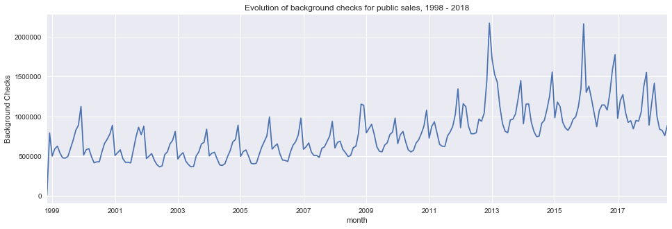

```python
# plotting the monthly amount of background checks related to public gun sales over time
sns.set_style("darkgrid")

plt.xlabel('Year')
plt.ylabel('Background Checks')
plt.title('Evolution of background checks for public sales, 1998 - 2018')
monthly['public_sales'].plot(kind='line', figsize=(16,5))

plt.show()
```

The time series plot reveals the presence of seasonality in the data, with big peaks of background checks in the end of each year (November - December). These peaks can be related to the holiday season sales starting with Black Friday sales in the end of November.

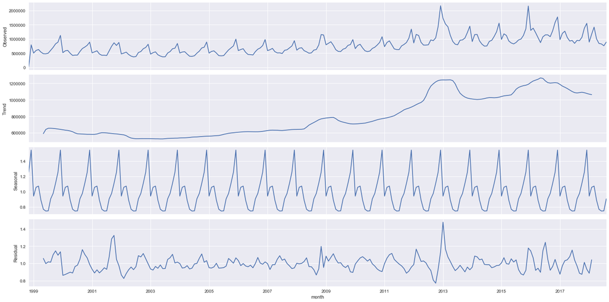

```python
# decomposing the time series into trend, seasonal and residual components
decompose = seasonal_decompose(monthly['public_sales'], model='multiplicative')

plt.rcParams["figure.figsize"] = (20,10)
decompose.plot()
plt.show()
```

The trend component shows a clear upward trend in background checks over the past 20 years. Let's smooth the data using moving averages to see any peaks in the data that are not related to the seasonality.

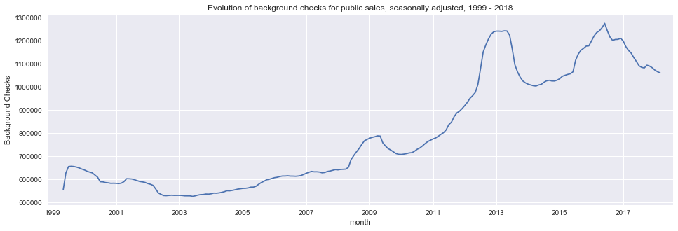

```python
# smoothing the time series using moving averages
monthly['sales_ma'] = monthly['public_sales'].rolling(window=12, center=True).mean()

plt.xlabel('Year')
plt.ylabel('Background Checks')
plt.title('Evolution of background checks for public sales, seasonally adjusted, 1999 - 2018')
monthly['sales_ma'].plot(figsize=(16,5))

plt.show()
```

Looking at the evolution of background checks adjusted for seasonality, there are some peaks in data that are not related to the seasonal component:

- **End of 2008**: coincides with Obama first election
- **End of 2012**: coincides with Obama second election and the Sandy Hook Elementary School shooting
- **End of 2015 - Beginning of 2016**: San Bernardino and Orlando mass shootings

According to a [New York Times article](https://www.nytimes.com/interactive/2015/12/10/us/gun-sales-terrorism-obama-restrictions.html) that analysed trends in gun sales, there is:

> a pattern of spikes in sales after terrorist attacks and calls for stricter gun-buying laws

### Q2: What is the split of sales by gun type?

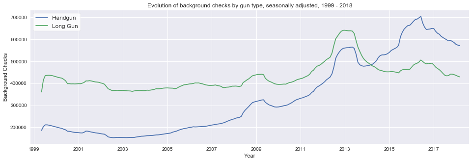

```python
# calculating a moving average by gun type
monthly['handgun_ma'] = monthly['handgun'].rolling(window=12, center=True).mean()
monthly['long_gun_ma'] = monthly['long_gun'].rolling(window=12, center=True).mean()

monthly[['handgun_ma', 'long_gun_ma']].plot(kind='line', figsize=(16,5))
plt.xlabel('Year')
plt.ylabel('Background Checks')
plt.title('Evolution of background checks by gun type, seasonally adjusted, 1999 - 2018')
plt.legend(('Handgun', 'Long Gun'), loc='upper left', fontsize=12, frameon=True, facecolor='white')

plt.show()
```

We can see from the graph that up until 2014, long guns were more in demand than hanguns. However, in 2014 the checks for handguns overcome the checks for long guns.

As for the spikes in demand for guns, they tend to affect both handguns and long guns similarly. Altough if we compare the spikes of the end of 2008 and 2012, with the most recent spike of the end of 2015 - beginning of 2016, it seems that the latter brought bigger increase in hangun sales compared to long gun sales.

Handguns are more associated with self-defense, and since the latest spike occured after several mass shootings, this could be a factor that would explain bigger surge of the demans for handguns.

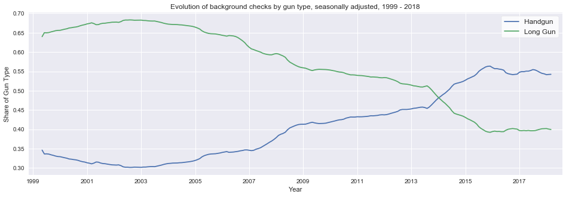

```python
# calculating a proportion of sales by gun type
monthly['handgun_share'] = (monthly['handgun'] / monthly['public_sales']).rolling(window=12, center=True).mean()
monthly['long_gun_share'] = (monthly['long_gun'] / monthly['public_sales']).rolling(window=12, center=True).mean()

monthly[['handgun_share', 'long_gun_share']].plot(kind='line', figsize=(16,5))
plt.xlabel('Year')
plt.ylabel('Share of Gun Type')
plt.title('Evolution of background checks by gun type, seasonally adjusted, 1999 - 2018')
plt.legend(('Handgun', 'Long Gun'), loc='upper right', fontsize=12, frameon=True, facecolor='white')

plt.show()
```

The evolution of background checks by gun type shows that while long guns constituted a larger proportion of sales in the past (up to 68% in 2003), they were overcome by handguns in 2014. In 2017 handguns approximately constituted 55% of all background checks, whereas long guns stayed at around 40% of all checks).

```python
# calculationg the split by gun type per state
by_state = df.groupby('state').mean()
by_state = by_state.sort_values(by='public_sales', ascending=True)

by_state['handgun_share'] = (by_state['handgun'] / by_state['public_sales'])
by_state['long_gun_share'] = (by_state['long_gun'] / by_state['public_sales'])
```

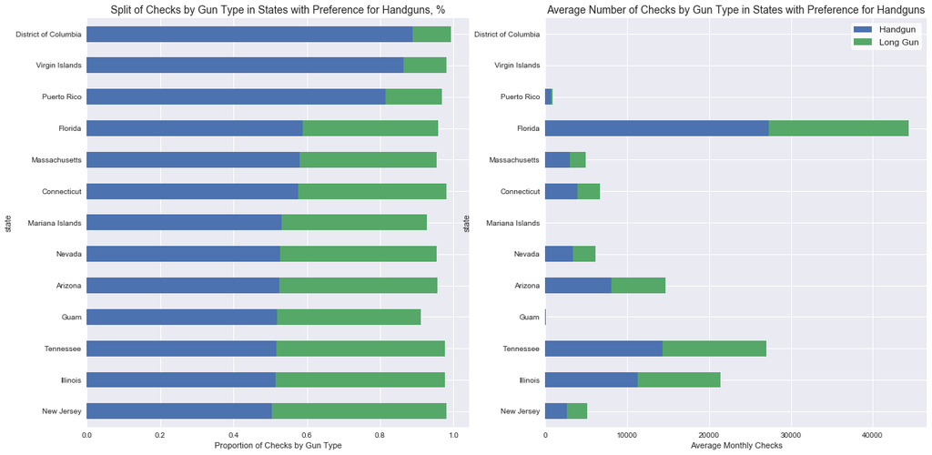

```python
# finding states with the majority of checks related to handguns
top_handgun = by_state[by_state['handgun_share'] > 0.5].sort_values(by='handgun_share', ascending=True)

fig = plt.figure()

ax1 = fig.add_subplot(121)
ax1.set_title('Split of Checks by Gun Type in States with Preference for Handguns, %', fontsize=14)
ax1.xaxis.set_label_text('Proportion of Checks by Gun Type')

top_handgun[['handgun_share', 'long_gun_share']].plot(kind='barh', stacked=True, ax=ax1, legend=None)

ax2 = fig.add_subplot(122)
ax2.set_title('Average Number of Checks by Gun Type in States with Preference for Handguns', fontsize=14)
ax2.xaxis.set_label_text('Average Monthly Checks')
ax2.legend(loc='upper right', fontsize=14, frameon=True, facecolor='white')

top_handgun[['handgun', 'long_gun']].plot(kind='barh', stacked=True, ax=ax2)

plt.legend(('Handgun', 'Long Gun'), loc='upper right', fontsize=12, frameon=True, facecolor='white')

plt.show()
```

From the graph we can see that top 3 states with stronger preference for handguns over long guns have very low amount of monthly background checks (less than 1,000 per month). The top 3 states with highest amount of checks per month out of the states that have preference to handguns over long guns are:

- Florida
- Tennessee
- Illinois

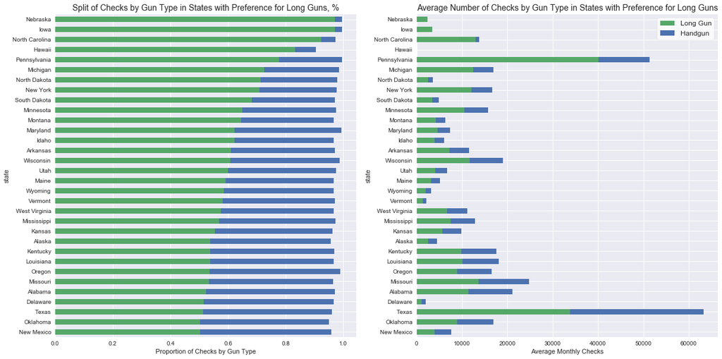

```python
# finding states with the majority of checks related to long guns
top_long_gun = by_state[by_state['long_gun_share'] > 0.5].sort_values(by='long_gun_share', ascending=True)

fig = plt.figure()

ax1 = fig.add_subplot(121)
ax1.set_title('Split of Checks by Gun Type in States with Preference for Long Guns, %', fontsize=14)
ax1.xaxis.set_label_text('Proportion of Checks by Gun Type')

top_long_gun[['long_gun_share', 'handgun_share']].plot(kind='barh', stacked=True, ax=ax1, legend=None, color=\
                                                            (sns.color_palette("deep")[1], sns.color_palette("deep")[0]))

ax2 = fig.add_subplot(122)
ax2.set_title('Average Number of Checks by Gun Type in States with Preference for Long Guns', fontsize=14)
ax2.xaxis.set_label_text('Average Monthly Checks')
ax2.legend(('Long Gun', 'Handgun'), loc='upper right', fontsize=14, frameon=True, facecolor='white')

top_long_gun[['long_gun', 'handgun']].plot(kind='barh', stacked=True, ax=ax2, color=\
                                                            (sns.color_palette("deep")[1], sns.color_palette("deep")[0]))

plt.legend(('Long Gun', 'Handgun'), loc='upper right', fontsize=12, frameon=True, facecolor='white')

plt.show()
```

Overall, there are more states with preference for long guns, but we must take into account that although historically long guns constituted larger proportion of sales, since 2014 they were overcome by the handguns, so it is possible that in the upcoming years more states will have a higher preference for handguns.

### Q3: Which states have had the highest growth in gun registrations?

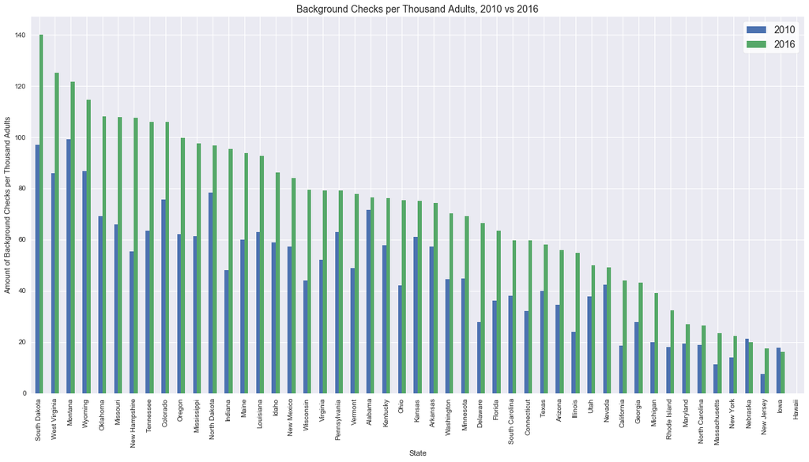

```python
# comparing amount of background checks in 2010 vs 2016 per state
cmb[['sales_per_mille_10', 'sales_per_mille_16']].sort_values(by='sales_per_mille_16', ascending=False).plot(kind='bar')
plt.xlabel('State')
plt.ylabel('Amount of Background Checks per Thousand Adults')
plt.title('Background Checks per Thousand Adults, 2010 vs 2016', fontsize=14)
plt.legend(('2010', '2016'), loc='upper right', fontsize=14, frameon=True, facecolor='white')

plt.show()
```

All of the states, except for Nebraska and Iowa, have experienced an increase in background checks per adult from 2010 to 2016.

```python
# calculating growth rate of sales per thousand adults from 2010 to 2016
cmb['spm_abs_growth'] = cmb['sales_per_mille_16'] - cmb['sales_per_mille_10']
cmb['spm_growth_rate'] = 100*(cmb['sales_per_mille_16'] - cmb['sales_per_mille_10'])/cmb['sales_per_mille_10']
```

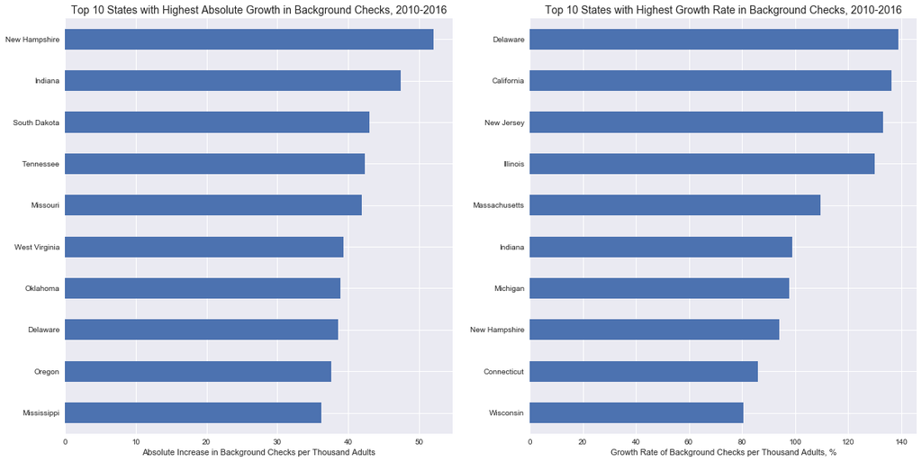

```python
# finding states with highest increase in background checks from 2010 to 2016
fig = plt.figure()

ax1 = fig.add_subplot(121)
ax1.set_title('Top 10 States with Highest Absolute Growth in Background Checks, 2010-2016', fontsize=14)
ax1.xaxis.set_label_text('Absolute Increase in Background Checks per Thousand Adults')

cmb['spm_abs_growth'].sort_values(ascending=True).iloc[-10:].plot(kind='barh', ax=ax1)

ax2 = fig.add_subplot(122)
ax2.set_title('Top 10 States with Highest Growth Rate in Background Checks, 2010-2016', fontsize=14)
ax2.xaxis.set_label_text('Growth Rate of Background Checks per Thousand Adults, %')

cmb['spm_growth_rate'].dropna().sort_values(ascending=True).iloc[-10:].plot(kind='barh', ax=ax2)

plt.show()
```

Here is the list of top 10 states with highest increase of background checks per adult, in terms of absolute increase and in terms of growth rate. In some states the amount of background checks more than doubled.

The states with the highest absolute increase in background checks per capita are:

- New Hampshire
- Indiana
- South Dakota

The states with the highest growth rate in background checks per capita are:

- Delaware
- California
- New Jersey

The following states appeared in top 10 highest increase of background checks per adult, both in terms of absolute increase and in terms of growth rate:

- New Hampshire
- Indiana
- Delaware

### Q4: Which census data is related to higher gun sales?

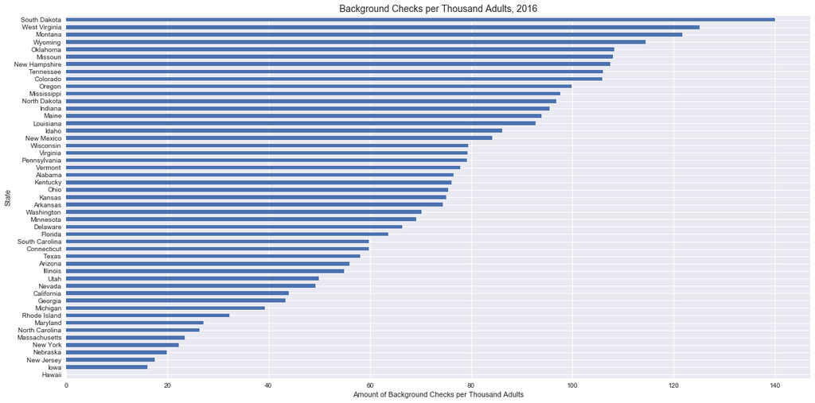

```python
# ordering states by the amount of checks per thousand adults in 2016
cmb['sales_per_mille_16'].sort_values(ascending=True).plot(kind='barh')
plt.xlabel('Amount of Background Checks per Thousand Adults')
plt.ylabel('State')
plt.title('Background Checks per Thousand Adults, 2016', fontsize=14)

plt.show()
```

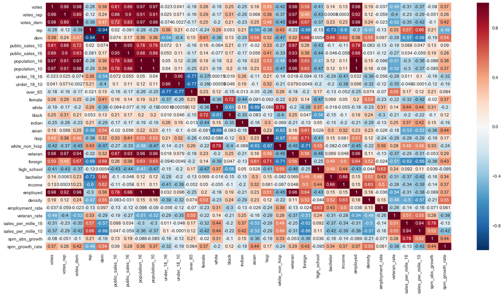

```python
# building a correlation matrix
corr = cmb.corr()
sns.heatmap(corr, xticklabels=corr.columns.values, yticklabels=corr.columns.values, annot=True)
```

From the correlation matrix we can see that the variables that have the highest correlation with the amount of background checks per capita are:

- election results (positive correlation with votes for republicans, negative correlation with votes for democrats)
- white non hispanic: positive correlation
- veteran: positive correlation
- asian: negative correlation
- foreign: negative correlation

Let's look at each of those variables separately.

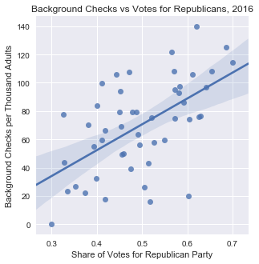

```python
# building a scatterplot for republican votes proportion vs background checks per capita
sns.lmplot(x='rep', y='sales_per_mille_16', data=cmb, size=4.5, fit_reg=True)

plt.title('Background Checks vs Votes for Republicans, 2016')
plt.xlabel('Share of Votes for Republican Party')
plt.ylabel('Background Checks per Thousand Adults')

plt.show()
```

There is a moderate positive correlation between the share of votes in favor of Republican party and the amount of background checks per thousand adults. The states where Republicans received higher proportion of votes compared to Democrats have also shown higher amount of background checks per adult.

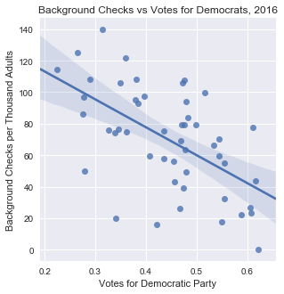

```python
# building a scatterplot for democrat votes proportion vs background checks per capita
sns.lmplot(x='dem', y='sales_per_mille_16', data=cmb, size=4.5, fit_reg=True)

plt.title('Background Checks vs Votes for Democrats, 2016')
plt.xlabel('Votes for Democratic Party')
plt.ylabel('Background Checks per Thousand Adults')

plt.show()
```

As opposed to votes in favor of Republicans, there is a negative correlation between the share of votes in favor of Democratic party and the amount of background checks per thousand adults.

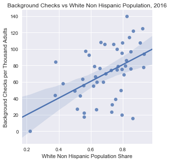

```python
# building a scatterplot for white non hispanic population share vs background checks per capita
sns.lmplot(x='white_non_hisp', y='sales_per_mille_16', data=cmb, size=4.5, fit_reg=True)

plt.title('Background Checks vs White Non Hispanic Population, 2016')
plt.xlabel('White Non Hispanic Population Share')
plt.ylabel('Background Checks per Thousand Adults')

plt.show()
```

There is a slight positive correlation between the share of white non-hispanic population and the amount of background checks per thousand adults. The states with higher share of white non-hispanic population tend to have more background checks per adult.

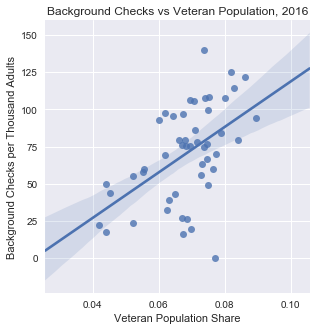

```python
# building a scatterplot for veteran population share vs background checks per capita
sns.lmplot(x='veteran_rate', y='sales_per_mille_16', data=cmb, size=4.5, fit_reg=True)

plt.title('Background Checks vs Veteran Population, 2016')
plt.xlabel('Veteran Population Share')
plt.ylabel('Background Checks per Thousand Adults')

plt.show()
```

We can witness a positive correlation between the percentage of veterans per state and the amount of background checks. The higher the percentage of veteran population, the more background checks per adult tend to be registered in a state.

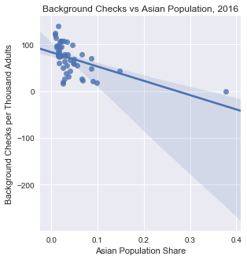

```python
# building a scatterplot for asian population share vs background checks per capita
sns.lmplot(x='asian', y='sales_per_mille_16', data=cmb, size=4.5, fit_reg=True)

plt.title('Background Checks vs Asian Population, 2016')
plt.xlabel('Asian Population Share')
plt.ylabel('Background Checks per Thousand Adults')

plt.show()
```

Looking at the scatterplot, there is a clear outlier with a lot higher proportion of asian population than the rest. Let's see if the picture changes after removing the outlier.

```python
#checking the outlier value
cmb.sort_values(by='asian', ascending=False).head(1)
```

|  | votes | votes_rep | votes_dem | rep | dem | public_sales_10 | public_sales_16 | population_16 | population_10 | under_18_16 | ... | bachelor | income | employed | density | employment_rate | veteran_rate | sales_per_mille_16 | sales_per_mille_10 | spm_abs_growth | spm_growth_rate |
| --- | --- | --- | --- | --- | --- | --- | --- | --- | --- | --- | --- | --- | --- | --- | --- | --- | --- | --- | --- | --- | --- |
| Hawaii | 428825.0 | 128815.0 | 266827.0 | 0.300391 | 0.622228 | 0.0 | 0.0 | 1428557 | 1360301 | 0.216 | ... | 0.308 | 29822 | 523677 | 211.8 | 0.598 | 0.0772 | 0.0 | 0.0 | 0.0 | NaN |

1 rows × 32 columns

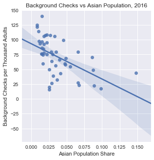

```python
# building a scatterplot for asian population share vs background checks per capita after removing Hawaii outlier
cmb_without_hawaii = cmb.drop('Hawaii', axis=0)

sns.lmplot(x='asian', y='sales_per_mille_16', data=cmb_without_hawaii, size=4.5, fit_reg=True)

plt.title('Background Checks vs Asian Population, 2016')
plt.xlabel('Asian Population Share')
plt.ylabel('Background Checks per Thousand Adults')

plt.show()
```

Even after removing Hawaii, there still seems to be a slight negative correlation between the share of Asian population and the amount of background checks per adult.

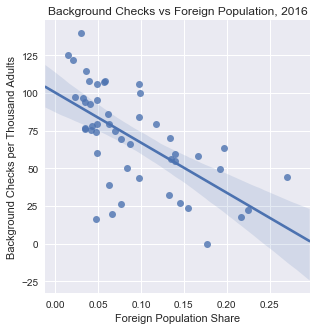

```python
# building a scatterplot for foreign population share vs background checks per capita
sns.lmplot(x='foreign', y='sales_per_mille_16', data=cmb, size=4.5, fit_reg=True)

plt.title('Background Checks vs Foreign Population, 2016')
plt.xlabel('Foreign Population Share')
plt.ylabel('Background Checks per Thousand Adults')

plt.show()
```

There is a slight negative correlation between the percentage of foreign population and the amount of background checks, meaning that the states with higher proportion of foreign population tend to have less background checks per thousand adults.

## Conclusions

**1- Trends and tendencies of gun purchases**

- There was an overall increasing trend of gun sales in the past 20 years
- Gun purchases are subject to seasonality, with the annual sales peak happening in November - December, coinciding with the holiday season sales period
- There were spikes in sales that coincided with external events, such as terrorist attacks and mass shootings, as well as the elections of candidates in favor of restricting gun regulations

**2- Gun sales by gun type**

- Historically long guns constituted higher proportion of sales compared to handguns
- Starting from 2014 this has changed and handguns have overcome long guns in popularity

**3- Which states have had the highest growth in gun registrations?**

- Almost all of the states have experienced an increase in background checks per capita between 2010 and 2016
- In some states the amount of background checks per capita more than doubled between 2010 and 2016
- The states with the highest absolute increase in background checks per capita are: New Hampshire, Indiana and South Dakota.

**4- What census data is most associated with high level of background checks per capita**

The following census data appears to be positively correlated with the level of background checks:

- share of votes for Republican party
- proportion of white non-hispanic population
- proportion of veterans

## List of References

- https://github.com/BuzzFeedNews/nics-firearm-background-checks
- https://data.opendatasoft.com/explore/dataset/usa-2016-presidential-election-by-county%40public/table/
- https://wfpl.org/kentucky-background-checks-stand-out/
- https://lawcenter.giffords.org/gun-laws/policy-areas/background-checks/universal-background-checks/
- https://www.nytimes.com/interactive/2015/12/10/us/gun-sales-terrorism-obama-restrictions.html